# What Factors Have the Greatest Impact on Fuel Consumption of Automobiles

# Questions of Interest

## Is an automatic or manual transmission better for MPG?

# Residual Plot, some Diagnostics and Uncertainty in the Model

An additional Residual Plot can be seen in **Figure 3** of the Appendix and illustrates the uncertainty in our Model. The graph on the upper left indicates a pattern, as the fitted values define a quadratic curve. This indicates, that our assumption of a linear model might be false. Actually we can see from the exploratory analysis, that mpg is probably not linear dependent from horsepower and weight. There also seem to be some leverage according to the graph on the lower right corner of the figure. Calling hatvalues shows that the Maserati Bora has the biggest leverage:

```r
rownames(mtcars[which.max(hatvalues(fit3)),])
```

```
## [1] "Maserati Bora"
```

Though, the model explains almost 83% of the variance, there is some uncertainty in our model, especially, because there is strong evidence that the actual model isn’t linear. Further analysis with nonlinear models is therefore recommended, but is out of scope of this report.

# Appendix

## Figure 1: How are variables related to eachother?

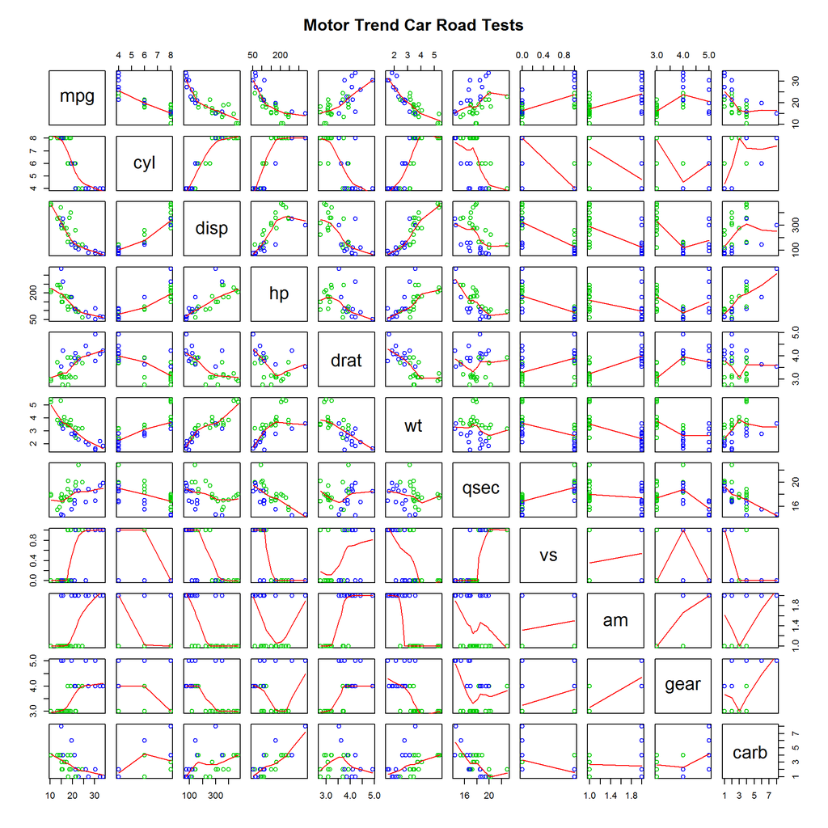

## Figure 2: Transmission vs. Miles per Gallon

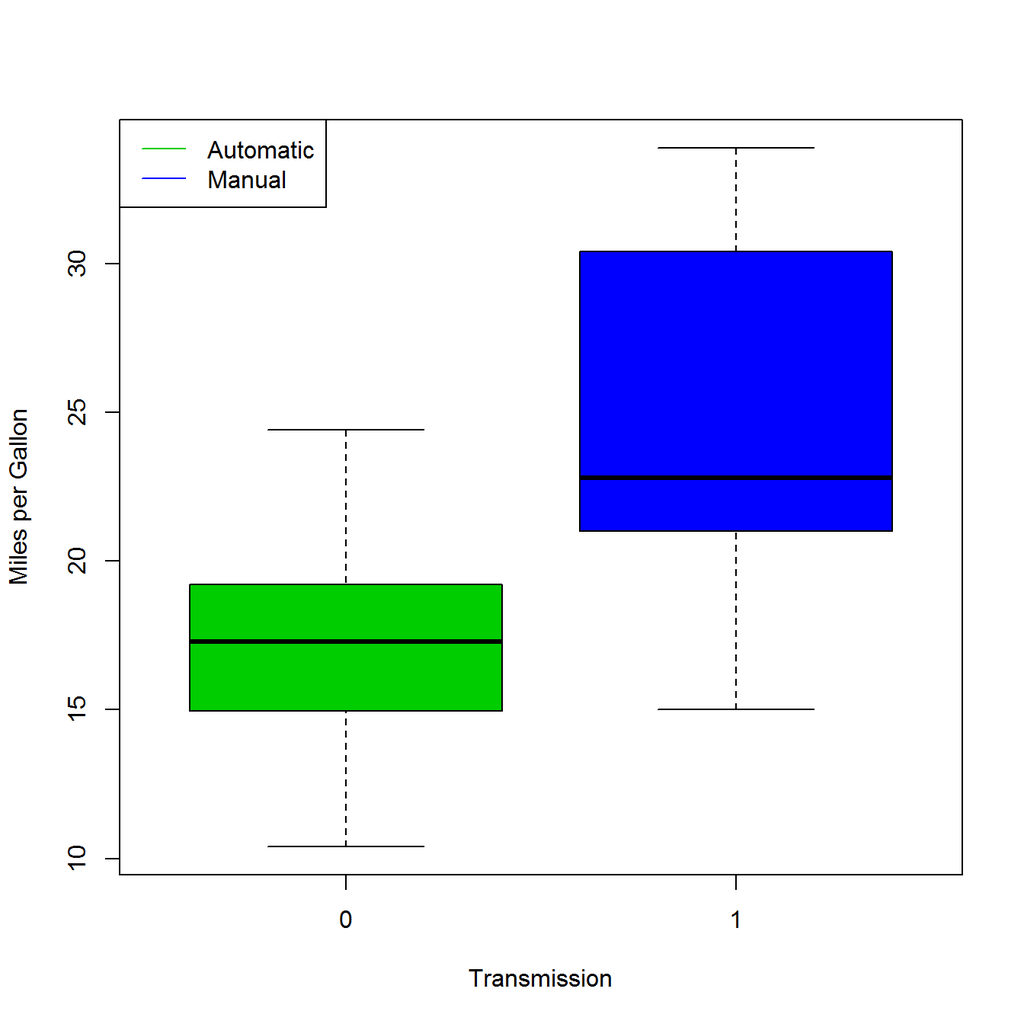

## Figure 3: Residual Plot

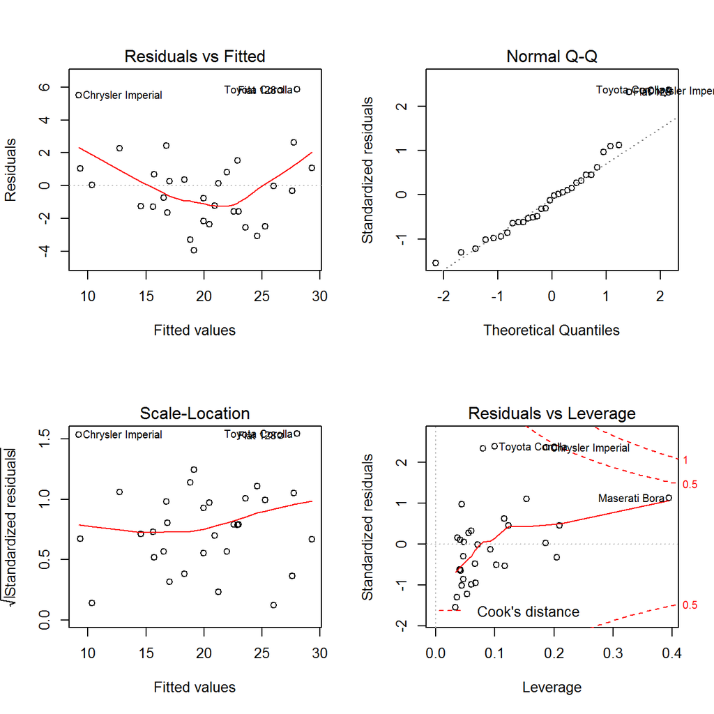